# RSA support analyses summaries

Last update: February 2, 2021

Daily passage, arrival, and peak of spawn exploratory analyses

This script takes the summary databases available from STAD programs. Some caveats to these data:

- There are no SEP channel data included
- Stellako data are questionable because a) changing program start dates may/may not capture Nadina, and b) uncertainty over the daily % Stellako/Nadina each year (DNA is not always taken each year so the opportunity to split daily passage by stock composition is not always known)
- Daily passage data are NOT intended to be used to generate escapement estimates/spawner abundances. much post-processing analysis is done to allocate sockeye to lake spawning, tributaries, channels, etc. These data should NEVER be summed to estimate total escapement.
- Daily passage code needs to be updated each year depending on the focal year of interest and which systems have useable programs (e.g., Quesnel only gets a sonar in its dominant year(s)).
- Forecast groups should be double-checked; taseko in particular might not be represented by forecast grouping value for all yrs (might just be a subset of years)
- Peak of spawn data: variable data quality exists based on effort (survey frequency and duration) so these should be taken with a grain of salt
- No controls for effort etc. made

## Arrival timing

The following information presents dates at which 10% of the total run passed the sonar or fence.

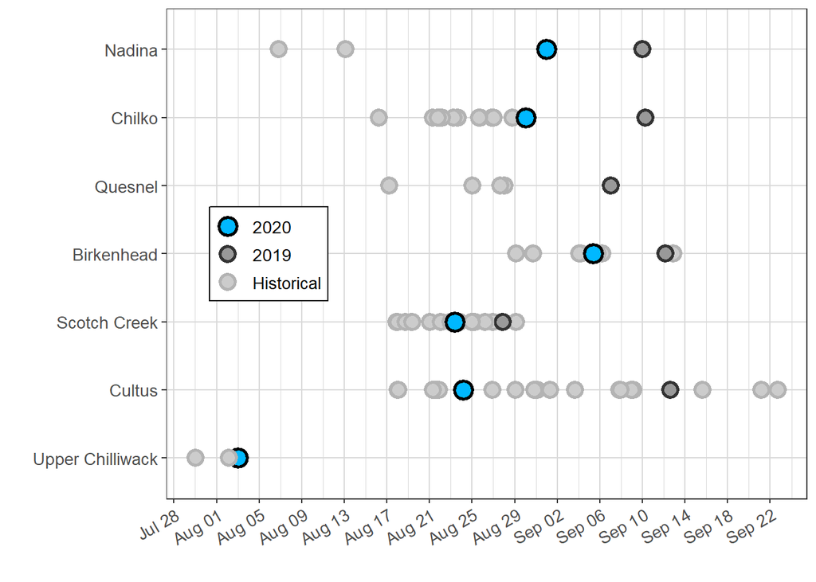

*Fig 1. 10% arrival timing dates for stocks with daily passage data available.*

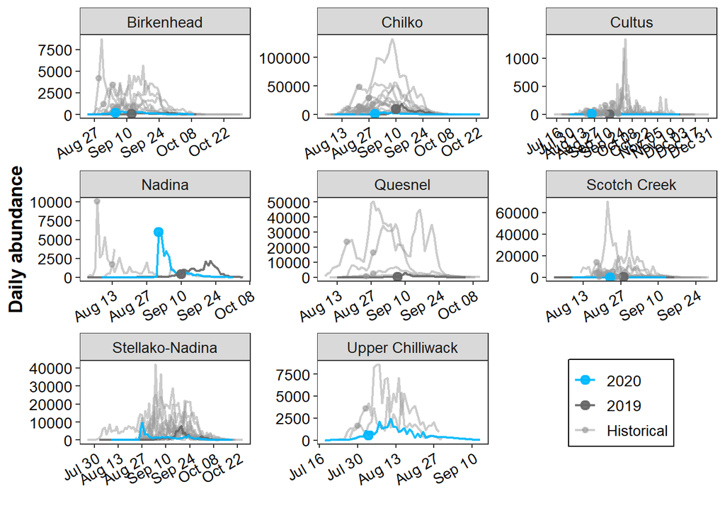

*Fig 2. Single stock arrivals for all populations with daily passage data. 'Stellako-Nadina' does not have 10% arrival date points due to uncertainties about parsing the two stocks apart at the Stellako weir.*

## Peak of spawn ranges

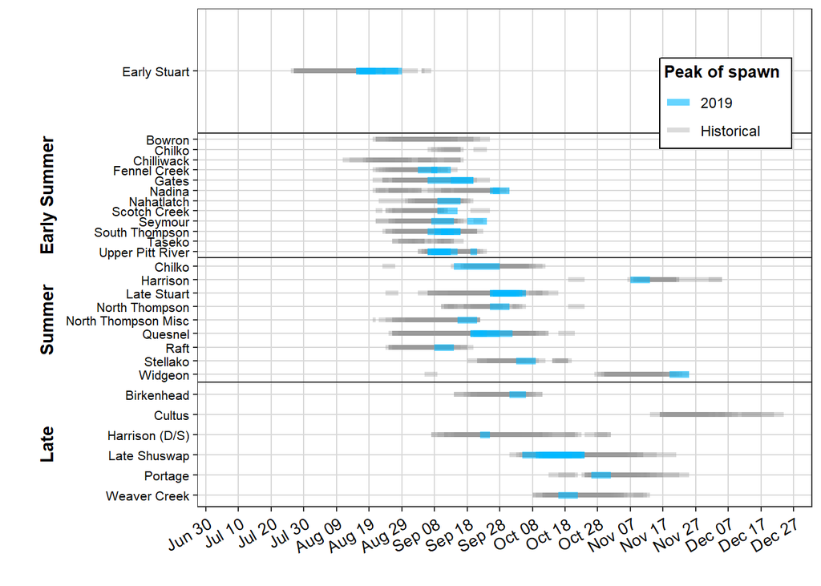

*Figure 3. Peak of spawn ranges for all available stocks and years from 2000-2019 (2020 not yet included in the DFO escapement database).*

## Nadina focal analysis

Request to share with PSC (SL, ET) Jan 11, 2021

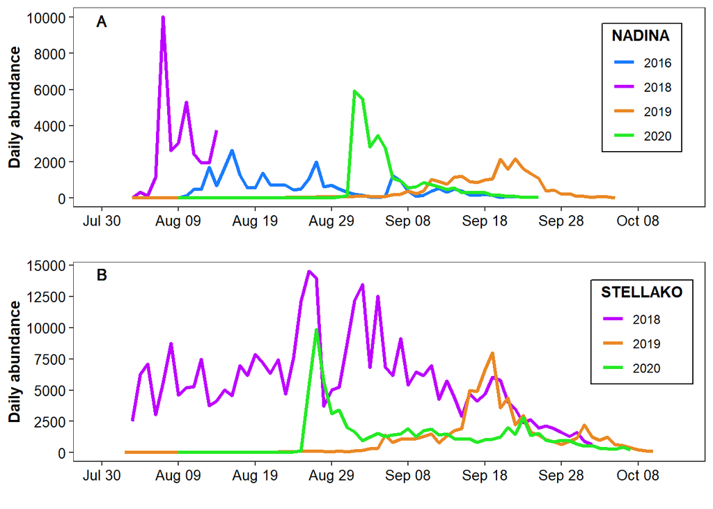

*Fig 4. a) Nadina and b) Stellako daily passage.*

## Taseko focal analysis

RSA share request Jan 14 2021

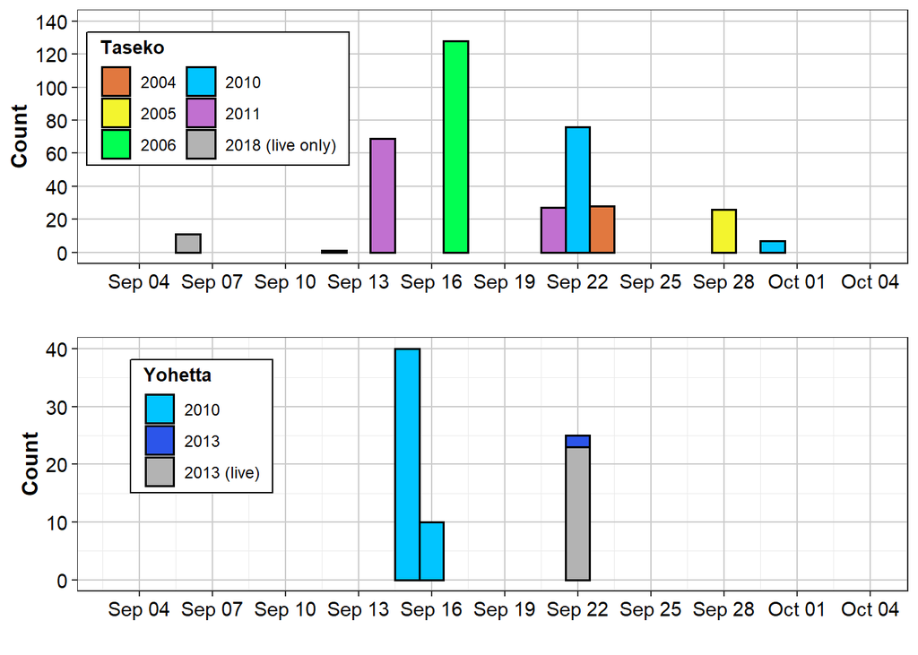

*Figure 5. a) Taseko and b) Yohetta survey data. Taseko carcass (colours) and live (gray) counts recorded on each survey (each bar) from 2003-2018. No record for a year means no survey or no sockeye (live or dead) recorded. Data source: 'taseko_roving'.*

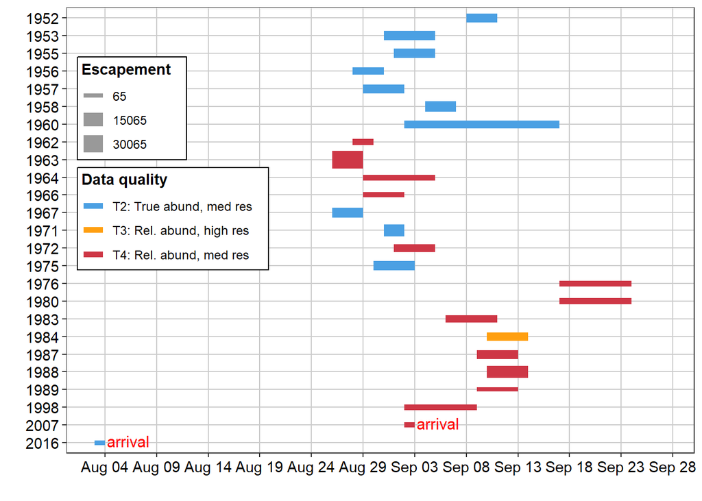

*Fig 6. Estimated annaul peak of spawn ranges for Taseko Lake. Bars are scaled by escapement size and coloured by program data quality (2007 and 2016 are arrival dates only). Type-2 data typically collected from high-certainty, high-precision methods (mark-recapture, SONAR, fence). Type-3 data typically collected from visual surveys or uncertain high-precision programs. Type-4 data from visual surveys with uncertainty, presence/absence, carcass expansions, etc. It is likely that the T3 data collected in 1984 should really be T4 data given the visibility of Taseko Lake and the relatively small escapement size. Data source: 'taseko_escapement'.*